# Avoir des enfants ou pas : une analyse des facteurs décisifs en France (1991-2019) - Partie 2

Romain Fehri

2024-12-20

# III. Tri des variables explicatives - Réduction des colinéarités

Nous avons vérifié la présence de **relations linéaires parfaites** entre les variables explicatives et avons supprimé les **variables redondantes**. Sans cette étape, certains coefficients ne seraient pas identifiables, ce qui poserait un **problème d’estimation**.

Cette vérification, réalisée après le nettoyage des données, est cruciale pour: - **Éviter les blocages mathématiques** dans la régression,  
- Garantir une **estimation stable**,  
- Et permettre une **interprétation claire** des coefficients.

Cette approche assure que notre modèle économétrique reste fiable et robuste, même dans des conditions où les variables explicatives présentent des interdépendances.

## III.1. Détection et traitement de la colinéarité parfaite (alias)

```r
model_alias <- lm(fec ~ ., data = data_work2 %>% select(-Temps))
alias_info <- alias(model_alias)
alias_matrix <- alias_info$Complete  # Matrice de colinéarités parfaites

# Vérifier si des alias existent
if (is.null(alias_matrix)) {
  cat("Aucune colinéarité parfaite détectée dans le modèle.\n")
} else {
  # Étape 4 : Identifier les variables colinéaires
  alias_pairs <- which(alias_matrix != 0, arr.ind = TRUE)

  # Extraire les noms des variables impliquées dans les colinéarités
  alias_summary <- data.frame(
    Variable_1 = rownames(alias_matrix)[alias_pairs[, 1]],
    Variable_2 = colnames(alias_matrix)[alias_pairs[, 2]]
  ) %>%
    distinct()

  # Afficher la liste des colinéarités parfaites
  cat("Colinéarités parfaites détectées :\n")
  print(alias_summary)
}
```

```
## Aucune colinéarité parfaite détectée dans le modèle.
```

```r
alias_vars <- rownames(alias_info$Complete)
cat("Variables impliquées dans les alias avec l'intercept :\n")
```

```
## Variables impliquées dans les alias avec l'intercept :
```

```r
print(alias_vars)
```

## III.2. Analyse de colinéarité entre variables explicatives (matrice de corrélation, heatmap, MDS)

Nous avons ensuite calculé la **matrice de corrélation** et visualisé les relations entre variables à l’aide de *heatmaps* et de *MDS* (*Multidimensional Scaling*). Ces outils permettent de détecter la **multicolinéarité non parfaite**, qui, bien que moins évidente, peut fragiliser l’estimation.

Cette étape approfondit: - L’analyse de la **redondance entre les variables**,  
- Et contribue à **affiner la sélection des variables** pour le modèle.

En identifiant les relations complexes entre variables explicatives, nous renforçons ainsi la fiabilité et la robustesse des résultats obtenus dans nos régressions.

```r
# Calculer la matrice de corrélation
cor_mat <- cor(data_expl, use = "complete.obs")

# Heatmap
correlation_melted <- melt(cor_mat)
heatmap_plot <- ggplot(correlation_melted, aes(x = Var1, y = Var2, fill = value)) +
  geom_tile(color = "white") +
  scale_fill_gradient2(low = "blue", high = "red", mid = "white", midpoint = 0,
                       limit = c(-1, 1), space = "Lab", name = "Corrélation") +
  theme_minimal() +
  theme(axis.text.x = element_text(angle = 45, vjust = 1, hjust = 1)) +
  labs(title = "Matrice de corrélation (data_work3)", x = "Variables", y = "Variables")
```

Nous obtenons la matrice de corrélation suivante, une fois le tri des variables effectué :

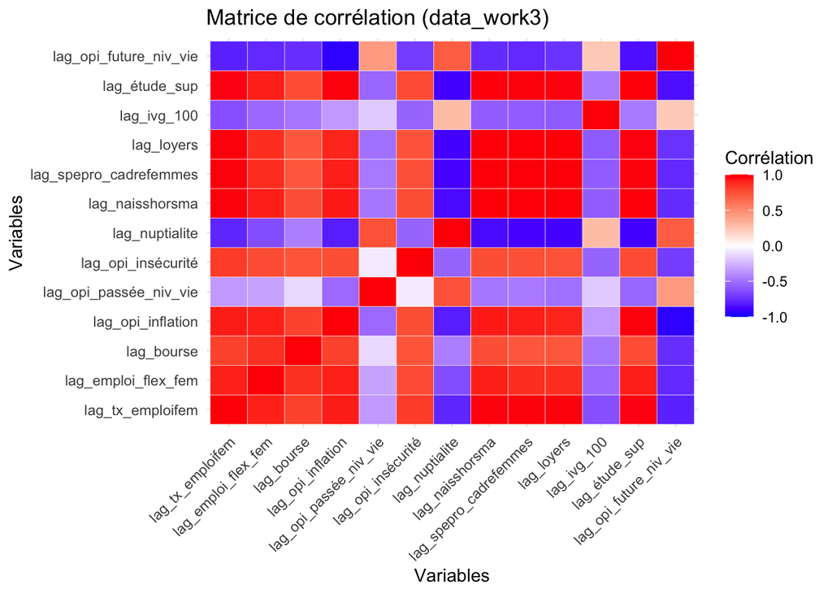

```r
print(heatmap_plot)
```

## Paires de variables avec corrélation > 0.5

```r
# Identification des paires de variables fortement corrélées
corr_threshold <- 0.5
high_corr_pairs <- correlation_melted %>%
  filter(value > corr_threshold & Var1 != Var2) %>%
  arrange(desc(value)) %>%
  mutate(pair = paste0(pmin(as.character(Var1), as.character(Var2)), "-", pmax(as.character(Var1), as.character(Var2)))) %>%
  distinct(pair, .keep_all = TRUE) %>%
  select(-pair)

cat("Paires de variables avec corrélation >", corr_threshold, ":\n")
```

```
## Paires de variables avec corrélation > 0.5 :
```

```r
print(high_corr_pairs)
```

```
##                      Var1                   Var2     value
## 1              lag_loyers lag_spepro_cadrefemmes 0.9943522
## 2              lag_loyers        lag_naisshorsma 0.9932138
## 3  lag_spepro_cadrefemmes        lag_naisshorsma 0.9915528
## 4           lag_étude_sup        lag_naisshorsma 0.9821608
## 5  lag_spepro_cadrefemmes       lag_tx_emploifem 0.9770770
## 6         lag_naisshorsma       lag_tx_emploifem 0.9767545
## 7              lag_loyers       lag_tx_emploifem 0.9722738
## 8           lag_étude_sup lag_spepro_cadrefemmes 0.9715334
## 9           lag_étude_sup      lag_opi_inflation 0.9711936
## 10          lag_étude_sup             lag_loyers 0.9658576
## 11          lag_étude_sup       lag_tx_emploifem 0.9565380
## 12        lag_naisshorsma      lag_opi_inflation 0.9258430
## 13      lag_opi_inflation       lag_tx_emploifem 0.9210560
## 14          lag_étude_sup    lag_emploi_flex_fem 0.9163227
```

[output cut: 24 more lines]

```r
# Compter les variables les plus fréquentes dans les paires corrélées
variable_counts <- high_corr_pairs %>%
  select(Var1, Var2) %>%
  pivot_longer(cols = everything(), values_to = "Variable") %>%
  group_by(Variable) %>%
  summarise(Frequency = n()) %>%
  arrange(desc(Frequency))

cat("\n### Variables les plus corrélées ###\n")
```

```
##
## ### Variables les plus corrélées ###
```

```r
print(variable_counts)
```

```
## # A tibble: 12 × 2
##    Variable               Frequency
##    <fct>                      <int>
##  1 lag_tx_emploifem               8
##  2 lag_emploi_flex_fem            8
##  3 lag_bourse                     8
##  4 lag_opi_inflation              8
##  5 lag_opi_insécurité             8
##  6 lag_naisshorsma                8
##  7 lag_spepro_cadrefemmes         8
##  8 lag_loyers                     8
##  9 lag_étude_sup                  8
## 10 lag_nuptialite                 2
## 11 lag_opi_passée_niv_vie         1
## 12 lag_opi_future_niv_vie         1
```

Nous avons ensuite visualisé graphiquement les clusters de variables

Nous obtenons le graphique MDS suivant, une fois le tri des variables effectué.

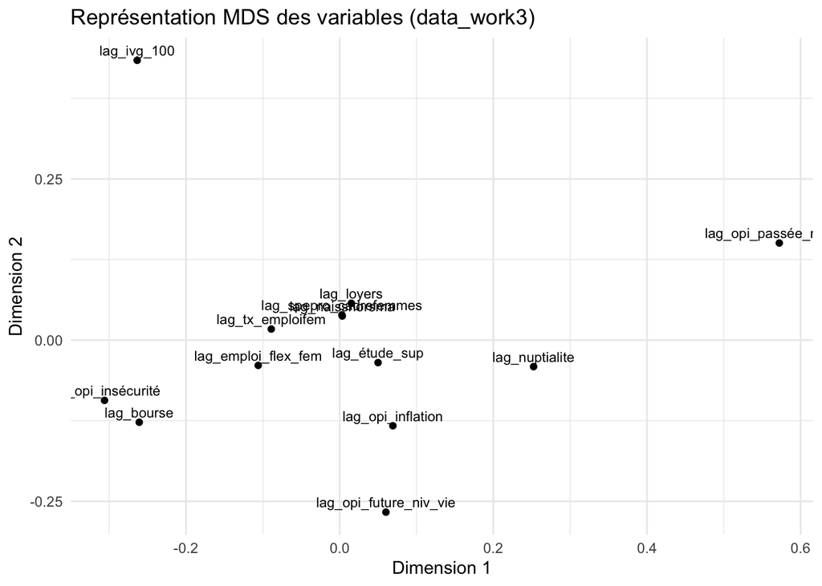

```r
### MDS (Multi-Dimensional Scaling)
mds_res <- cmdscale(dist_mat, k = 2)
mds_df <- data.frame(
  Dim1 = mds_res[,1],
  Dim2 = mds_res[,2],
  Variable = rownames(mds_res)
)

mds_plot <- ggplot(mds_df, aes(x = Dim1, y = Dim2, label = Variable)) +
  geom_point() +
  geom_text(vjust = -0.5, size = 3) +
  labs(title = "Représentation MDS des variables (data_work3)", x = "Dimension 1", y = "Dimension 2") +
  theme_minimal()

print(mds_plot)
```

```r
ggsave("//Users/mehdifehri/Desktop/R/Code Final Fec/MDS_Plot_Data_Work3.pdf", plot = mds_plot, width = 10, height = 8)
cat("MDS plot affiché et sauvegardé en PDF.\n")
```

```
## MDS plot affiché et sauvegardé en PDF.
```

## III.3. Réduction des variables à fort VIF (Facteur d’inflation de la variance) et création du DataFrame final

Ensuite, nous calculons le **Facteur d’inflation de la variance** (*Variance Inflation Factor*, VIF) pour chaque variable afin d’identifier et d’éliminer celles présentant une **multicolinéarité excessive**. Un **VIF élevé** est un indicateur que l’estimation du coefficient associé à une variable est **instable**, en raison d’une forte corrélation avec d’autres variables explicatives.

Cette étape, réalisée après l’analyse des corrélations, poursuit deux objectifs principaux: - **Réduire les redondances** entre variables explicatives,  
- Garantir un **jeu de variables final stable et fiable**, essentiel pour assurer la robustesse des estimations.

En somme, l’utilisation du VIF constitue une vérification cruciale pour prévenir les biais et améliorer la qualité globale du modèle.

Nous avons développé un **code spécifique** pour supprimer les variables présentant un **Facteur d’inflation de la variance** (*Variance Inflation Factor*, VIF) trop élevé.

Cette boucle itérative fonctionne selon le processus suivant: 1. **Calcul des VIF** pour toutes les variables explicatives.  
2. Suppression de la variable ayant le **VIF le plus élevé**.  
3. Répétition du processus jusqu’à ce que toutes les variables restantes aient un **VIF inférieur au seuil d’acceptabilité** que nous avons fixé arbitrairement.

Cette approche garantit que le modèle final est exempt de **multicolinéarité excessive**, améliorant ainsi la stabilité des estimations et la fiabilité des résultats.

```r
# Créer une copie des données pour le processus VIF
data_for_vif <- data_work3

# Définir le seuil de VIF
vif_threshold <- 777

# Initialiser les listes pour stocker les résultats
iteration_results <- list()
removed_variables <- data.frame(Iteration = integer(), Variable = character(), VIF_Value = numeric(), stringsAsFactors = FALSE)

# Boucle itérative pour supprimer les variables avec VIF élevé
iteration <- 1
while (TRUE) {
  cat("\n--- Itération", iteration, "---\n")

  # Ajuster un modèle linéaire avec les variables explicatives restantes
  current_model <- lm(fec ~ ., data = data_for_vif[, c("fec", variables_explicatives)])

  # Calculer le VIF pour chaque variable explicative
  vif_values <- vif(current_model)

  # Afficher les VIF actuels
  cat("Facteurs d'inflation de la variance (VIF) actuels :\n")
  print(vif_values)

  # Sauvegarder les résultats de l'itération
  iteration_results[[iteration]] <- data.frame(Variable = names(vif_values), VIF = vif_values, Iteration = iteration)

  # Identifier les variables avec un VIF supérieur au seuil
  high_vif_vars <- names(vif_values[vif_values > vif_threshold])

  # Vérifier s'il reste des variables avec un VIF élevé
  if (length(high_vif_vars) == 0) {
    cat("Toutes les variables ont un VIF <= ", vif_threshold, ". Fin de la boucle.\n")
    break
  }

  # Identifier la variable avec le VIF maximum
  variable_to_remove <- high_vif_vars[which.max(vif_values[high_vif_vars])]
  max_vif_value <- max(vif_values[high_vif_vars])
  cat("Variable avec le VIF le plus élevé :", variable_to_remove, "(", max_vif_value, ")\n")

  # Ajouter la variable supprimée à la liste des variables supprimées
  removed_variables <- rbind(removed_variables, data.frame(Iteration = iteration, Variable = variable_to_remove, VIF_Value = max_vif_value))

  # Supprimer cette variable des données et des variables explicatives
  data_for_vif <- data_for_vif %>% select(-all_of(variable_to_remove))
  variables_explicatives <- setdiff(variables_explicatives, variable_to_remove)

  # Augmenter le compteur d'itérations
  iteration <- iteration + 1
}
```

```
##
## --- Itération 1 ---
## Facteurs d'inflation de la variance (VIF) actuels :
##       lag_tx_emploifem    lag_emploi_flex_fem             lag_bourse
##              208.15180               49.03515               11.19224
##      lag_opi_inflation lag_opi_passée_niv_vie     lag_opi_insécurité
##              931.55531               38.74973                9.03091
##         lag_nuptialite        lag_naisshorsma lag_spepro_cadrefemmes
##               39.86942             1826.71470              399.74863
##             lag_loyers            lag_ivg_100          lag_étude_sup
##             1220.46904               11.33785              340.45413
## lag_opi_future_niv_vie
##              167.29854
## Variable avec le VIF le plus élevé : lag_naisshorsma ( 1826.715 )
##
## --- Itération 2 ---
## Facteurs d'inflation de la variance (VIF) actuels :
##       lag_tx_emploifem    lag_emploi_flex_fem             lag_bourse
##             205.632681              47.104865              11.174268
##      lag_opi_inflation lag_opi_passée_niv_vie     lag_opi_insécurité
##             603.677492              29.801181               6.867059
##         lag_nuptialite lag_spepro_cadrefemmes             lag_loyers
##              36.086191             396.145046             650.448233
##            lag_ivg_100          lag_étude_sup lag_opi_future_niv_vie
##               7.025430             201.558109              70.241146
## Toutes les variables ont un VIF <=  777 . Fin de la boucle.
```

Par exemple, la variable **‘naissance hors mariage’** a été supprimée, car son **Facteur d’inflation de la variance** (*VIF*) dépassait le seuil d’acceptabilité, indiquant une **colinéarité excessive** avec d’autres variables du modèle.

Cette approche garantit une **réduction progressive de la colinéarité**, ce qui contribue à: - Améliorer la **robustesse** des résultats,  
- Renforcer la **stabilité des estimations**,  
- Assurer une meilleure **interprétation des coefficients** dans le modèle final.

En somme, ce processus optimise la qualité de l’analyse économétrique en éliminant les interdépendances nuisibles entre variables explicatives.

# IV. Première régression OLS

## IV.1. Tests de spécification (RESET), choix de la meilleure forme fonctionnelle

Après avoir sélectionné et nettoyé nos variables, nous avons effectué le **test RESET** afin d’évaluer la spécification fonctionnelle du modèle. Ce test permet d’identifier d’éventuelles **erreurs de spécification**, telles que: - Des relations **non linéaires**,  
- L’omission de variables importantes.

Cette vérification est essentielle pour garantir que le modèle est **bien adapté aux données** et qu’il fournit des estimations **fiables**.

Nous avons choisi de tester **deux modèles**: 1. **Un modèle OLS sans transformation des variables explicatives.**  
2. **Un modèle OLS avec les variables explicatives transformées en logarithmes (*log*).**

*Remarque importante*:  
Notre variable d’intérêt **`fec`** (un taux de variation) **ne peut pas être transformée en logarithme**, car elle contient des valeurs négatives. Par conséquent, un modèle en *double log* est impossible.

Cependant, nous pouvons interpréter les résultats sans transformation comme une forme de **semi-élasticité** (taux de variation).  
De plus, en transformant uniquement les variables explicatives en logarithmes, nous obtenons une **lecture finale simplifiée** sous forme d’**élasticités**, ce qui facilite l’analyse et l’interprétation des résultats.

```r
# Modèle OLS de base
model_ols <- lm(fec ~ . - Temps, data = data_work4)
print(summary(model_ols))
```

```
##
## Call:
## lm(formula = fec ~ . - Temps, data = data_work4)
##
## Residuals:
##        Min         1Q     Median         3Q        Max
## -0.0076420 -0.0019002 -0.0002164  0.0016203  0.0076513
##
## Coefficients:
##                          Estimate Std. Error t value Pr(>|t|)
## (Intercept)            -3.471e-01  6.663e-02  -5.209 1.10e-06 ***
## lag_tx_emploifem        2.690e-03  1.531e-03   1.757  0.08214 .
## lag_emploi_flex_fem     4.218e-03  1.509e-03   2.795  0.00627 **
## lag_bourse              3.096e-05  4.307e-05   0.719  0.47401
## lag_opi_inflation       2.556e-04  1.057e-03   0.242  0.80951
## lag_opi_passée_niv_vie -1.391e-04  3.707e-04  -0.375  0.70836
## lag_opi_insécurité      9.389e-05  1.450e-04   0.647  0.51890
## lag_nuptialite         -2.506e-03  3.866e-03  -0.648  0.51849
## lag_spepro_cadrefemmes  5.096e-03  2.315e-03   2.202  0.03012 *
## lag_loyers             -9.253e-04  6.244e-04  -1.482  0.14169
## lag_ivg_100             5.178e-03  9.831e-04   5.267 8.61e-07 ***
## lag_étude_sup          -2.974e-03  9.238e-04  -3.219  0.00176 **
## lag_opi_future_niv_vie  1.527e-03  7.726e-04   1.976  0.05101 .
## ---
## Signif. codes:  0 '***' 0.001 '**' 0.01 '*' 0.05 '.' 0.1 ' ' 1
##
## Residual standard error: 0.00319 on 95 degrees of freedom
## Multiple R-squared:  0.571,  Adjusted R-squared:  0.5168
## F-statistic: 10.54 on 12 and 95 DF,  p-value: 6.263e-13
```

```r
# Création d'un modèle auxiliaire avec variables explicatives log
# Transformer les variables explicatives en log avec un préfixe et nettoyer les non-log
data_work4_log <- data_work4 %>%
  mutate(across(-c(Temps, fec), log, .names = "log_{.col}")) %>%
  select(Temps, fec, starts_with("log_"))
write_xlsx(data_work4_log, "//Users/mehdifehri/Desktop/R/Code Final Fec/Data_Work4_Log.xlsx")

# Modèle OLS avec les variables explicatives transformées en log
model_ols_log <- lm(fec ~ . - Temps, data = data_work4_log)
print(summary(model_ols_log))
```

```
##
## Call:
## lm(formula = fec ~ . - Temps, data = data_work4_log)
##
## Residuals:
##        Min         1Q     Median         3Q        Max
## -0.0064952 -0.0020716 -0.0001378  0.0016727  0.0074360
##
## Coefficients:
##                             Estimate Std. Error t value Pr(>|t|)
## (Intercept)                -1.370383   0.444582  -3.082 0.002687 **
## log_lag_tx_emploifem        0.184382   0.083306   2.213 0.029270 *
## log_lag_emploi_flex_fem     0.009079   0.020850   0.435 0.664219
## log_lag_bourse              0.010099   0.003414   2.959 0.003901 **
## log_lag_opi_inflation       0.061476   0.090954   0.676 0.500748
## log_lag_opi_passée_niv_vie -0.006790   0.010472  -0.648 0.518321
## log_lag_opi_insécurité     -0.002064   0.007721  -0.267 0.789842
## log_lag_nuptialite         -0.010763   0.017790  -0.605 0.546617
## log_lag_spepro_cadrefemmes  0.107647   0.030106   3.576 0.000552 ***
## log_lag_loyers             -0.163251   0.051072  -3.196 0.001890 **
## log_lag_ivg_100             0.163964   0.023169   7.077 2.51e-10 ***
## log_lag_étude_sup          -0.045595   0.023415  -1.947 0.054460 .
## log_lag_opi_future_niv_vie  0.106393   0.037077   2.870 0.005066 **
## ---
## Signif. codes:  0 '***' 0.001 '**' 0.01 '*' 0.05 '.' 0.1 ' ' 1
##
## Residual standard error: 0.003144 on 95 degrees of freedom
## Multiple R-squared:  0.5833, Adjusted R-squared:  0.5307
## F-statistic: 11.08 on 12 and 95 DF,  p-value: 1.737e-13
```

```r
# Test RESET pour le modèle OLS (base)
cat("\n### Test RESET pour le modèle OLS ###\n")
```

```
##
## ### Test RESET pour le modèle OLS ###
```

```r
reset_test_ols <- resettest(model_ols, power = 2:3, type = "fitted")
print(reset_test_ols)
```

```
##
##  RESET test
##
## data:  model_ols
## RESET = 0.085531, df1 = 2, df2 = 93, p-value = 0.9181
```

```r
if (reset_test_ols$p.value > 0.05) {
  cat("\nInterprétation : Le modèle de base est correctement spécifié. (p-value =", reset_test_ols$p.value, ")\n")
} else {
  cat("\nInterprétation : Le modèle de base est mal spécifié. (p-value =", reset_test_ols$p.value, ")\n")
}
```

```
##
## Interprétation : Le modèle de base est correctement spécifié. (p-value = 0.9180968 )
```

```r
# Test RESET pour le modèle OLS log-transformé
cat("\n### Test RESET pour le modèle OLS (log-transformé) ###\n")
```

```
##
## ### Test RESET pour le modèle OLS (log-transformé) ###
```

```r
reset_test_ols_log <- resettest(model_ols_log, power = 2:3, type = "fitted")
print(reset_test_ols_log)
```

```
##
##  RESET test
##
## data:  model_ols_log
## RESET = 0.74064, df1 = 2, df2 = 93, p-value = 0.4796
```

```r
if (reset_test_ols_log$p.value > 0.05) {
  cat("\nInterprétation : Le modèle log-transformé est correctement spécifié. (p-value =", reset_test_ols_log$p.value, ")\n")
} else {
  cat("\nInterprétation : Le modèle log-transformé est mal spécifié. (p-value =", reset_test_ols_log$p.value, ")\n")
}
```

```
##
## Interprétation : Le modèle log-transformé est correctement spécifié. (p-value = 0.4795998 )
```

Comme indiqué, **notre modèle log-transformé est correctement spécifié**

## IV.2. Choix de la meilleure transformation : Transformation logarithmique des variables explicatives et régression OLS

Après avoir vérifié que les deux formes fonctionnelles sont correctement spécifiées, nous procédons à une **comparaison de leurs performances** afin de sélectionner le modèle le plus performant.

Cette comparaison implique l’évaluation des critères suivants: - **Ajustement du modèle** : Analyse de la qualité de l’ajustement aux données observées.  
- **Significativité des coefficients** : Vérification de la pertinence statistique des variables explicatives.  
- **Critères d’information** : Utilisation de mesures telles que le *Critère d’Information d’Akaike* (AIC) ou le *Critère d’Information Bayésien* (BIC) pour comparer les modèles.  
- **Analyse des résidus** : Inspection des résidus pour détecter toute violation des hypothèses du modèle, comme l’homoscédasticité ou la normalité des erreurs.

En évaluant ces aspects, nous visons à identifier la transformation qui offre le meilleur équilibre entre **simplicité** et **précision prédictive**, garantissant ainsi des estimations fiables et une interprétation aisée des résultats.

```r
# Initialisation du tableau récapitulatif
model_comparison <- data.frame(
  Model = character(),
  Adjusted_R2 = numeric(),
  AIC = numeric(),
  BIC = numeric(),
  RESET_p_value = numeric(),
  RESET_Interpretation = character(),
  stringsAsFactors = FALSE
)

# Remplir le tableau pour chaque modèle
models <- list(
  "Model OLS" = model_ols,
  "Model OLS (Log)" = model_ols_log
)

# Fonction pour obtenir l'interprétation du test RESET
perform_reset <- function(model) {
  reset_results <- resettest(model, power = 2:3, type = "fitted")
  if (reset_results$p.value > 0.05) {
    interpretation <- "Correctement spécifié"
  } else {
    interpretation <- "Mal spécifié"
  }
  return(list(p_value = reset_results$p.value, interpretation = interpretation))
}

# Remplir le tableau avec les résultats pour chaque modèle
for (name in names(models)) {
  model <- models[[name]]
  summary_model <- summary(model)
  reset_results <- perform_reset(model)

  model_comparison <- rbind(model_comparison, data.frame(
    Model = name,
    Adjusted_R2 = summary_model$adj.r.squared,
    AIC = AIC(model),
    BIC = BIC(model),
    RESET_p_value = reset_results$p_value,
    RESET_Interpretation = reset_results$interpretation
  ))
}

# Afficher le tableau comparatif des modèles
print(model_comparison)
```

```
##             Model Adjusted_R2       AIC       BIC RESET_p_value
## 1       Model OLS   0.5167840 -920.8826 -883.3328     0.9180968
## 2 Model OLS (Log)   0.5306724 -924.0322 -886.4824     0.4795998
##    RESET_Interpretation
## 1 Correctement spécifié
## 2 Correctement spécifié
```

Sur la base de ces résultats, le **modèle logarithmique** s’est révélé plus performant. Nous avons donc décidé d’appliquer une transformation logarithmique à nos variables explicatives afin de simplifier l’interprétation finale.

*Remarque importante*:  
Notre variable d’intérêt, **`fec`**, qui représente un taux de variation, ne peut pas être transformée en logarithme en raison de la présence de valeurs négatives. Par conséquent, un modèle en *double log* n’est pas envisageable.

Cependant, les résultats sans transformation peuvent être interprétés en termes de **semi-élasticité**. La transformation logarithmique des variables explicatives permet d’obtenir une lecture finale simplifiée sous forme d’**élasticité**, facilitant ainsi l’interprétation des relations entre les variables.

## IV.3. Suppression des outliers dans notre modèle final réduit OLS log et nouvelle régression

```r
# Définition des variables explicatives (exclusion de "Temps" et "fec")
variables_explicatives_ols <- setdiff(colnames(data_work4_log), c("Temps", "fec"))

model_final <- lm(as.formula(paste("fec ~", paste(variables_explicatives_ols, collapse = " + "))), data = data_work4_log)

# Extraction des résidus
residus <- residuals(model_final)

# Seuil pour les outliers (par exemple, 2 fois l'écart-type des résidus)
threshold <- 1.75 * sd(residus)

# Suppression des outliers
data_work4_log_out <- data_work4_log %>%
  mutate(Residus = residus) %>%
  filter(abs(Residus) <= threshold) %>%
  select(-Residus)  # Retirer la colonne temporaire "Residus"

# Régression OLS après suppression des outliers
model_after_outliers <- lm(as.formula(paste("fec ~", paste(variables_explicatives_ols, collapse = " + "))),
                           data = data_work4_log_out)

# Résumé du modèle ajusté après suppression des outliers
cat("\nRésumé du modèle OLS après suppression des outliers:\n")
```

```
##
## Résumé du modèle OLS après suppression des outliers:
```

```r
print(summary(model_after_outliers))
```

```
##
## Call:
## lm(formula = as.formula(paste("fec ~", paste(variables_explicatives_ols,
##     collapse = " + "))), data = data_work4_log_out)
##
## Residuals:
##        Min         1Q     Median         3Q        Max
## -0.0053810 -0.0014559  0.0002217  0.0014332  0.0059504
##
## Coefficients:
##                              Estimate Std. Error t value Pr(>|t|)
## (Intercept)                -1.3567073  0.3528741  -3.845 0.000236 ***
## log_lag_tx_emploifem        0.3298554  0.0633586   5.206 1.37e-06 ***
## log_lag_emploi_flex_fem     0.0297938  0.0162163   1.837 0.069749 .
## log_lag_bourse              0.0061497  0.0024903   2.469 0.015582 *
## log_lag_opi_inflation      -0.0482118  0.0713483  -0.676 0.501093
## log_lag_opi_passée_niv_vie -0.0201023  0.0078389  -2.564 0.012136 *
## log_lag_opi_insécurité      0.0008462  0.0066024   0.128 0.898326
## log_lag_nuptialite         -0.0047327  0.0134069  -0.353 0.724982
## log_lag_spepro_cadrefemmes  0.1028937  0.0214902   4.788 7.26e-06 ***
## log_lag_loyers             -0.1821771  0.0368513  -4.944 3.94e-06 ***
## log_lag_ivg_100             0.1739499  0.0164863  10.551  < 2e-16 ***
## log_lag_étude_sup          -0.0317902  0.0172542  -1.842 0.068977 .
## log_lag_opi_future_niv_vie  0.0706104  0.0301585   2.341 0.021614 *
## ---
## Signif. codes:  0 '***' 0.001 '**' 0.01 '*' 0.05 '.' 0.1 ' ' 1
##
## Residual standard error: 0.0022 on 83 degrees of freedom
## Multiple R-squared:  0.7162, Adjusted R-squared:  0.6752
## F-statistic: 17.46 on 12 and 83 DF,  p-value: < 2.2e-16
```

Cette augmentation significative indique que l’élimination des données atypiques a permis d’améliorer la qualité de l’ajustement du modèle, renforçant ainsi la **précision** et la **fiabilité** des estimations obtenues.

## IV.4. Modèle final, visualisation des résidus

## Visualisation des résidus

[figure not shown]

```r
# Résidus vs valeurs ajustées
plot(fitted(model_final), residus, main = "Résidus vs valeurs ajustées",
     xlab = "Valeurs ajustées", ylab = "Résidus", pch = 19, col = "blue")
abline(h = 0, col = "red", lty = 2)
```

[figure not shown]

```r
# Résidus vs indices
plot(1:length(residus), residus, main = "Résidus vs indices",
     xlab = "Indice", ylab = "Résidus", pch = 19, col = "green")
abline(h = 0, col = "red", lty = 2)
```

[figure not shown]

```r
# Histogramme des résidus
hist(residus, breaks = 15, col = "gray", main = "Histogramme des résidus", xlab = "Résidus")
```

[figure not shown]

```r
# QQ-Plot des résidus
qqnorm(residus, main = "Q-Q Plot des résidus")
qqline(residus, col = "red")
```